# Feather River Habitat Suitability Index Development

Maddee Rubenson (FlowWest)

2025-03-25

### Adapted Mark Gard HSI process

adapted from https://github.com/FlowWest/va-feather-river-analysis/blob/mini-snorkel/analysis/feather_river_mini_snorkel_hsi_analysis_exploration.md

[Mark Gard’s 1998 paper](https://personales.upv.es/fmcapel/data/Technique%20for%20Adjusting%20Spawning%20Depth%20Habitat%20Utilization%20Curves%20for%20Availability.pdf) identified a method to developing HSC for presence and absence of redds in different substrate classes. I will follow the same methodology using fish presence/absence and total fish count instead of redds and also apply to cover.

1. Determine number of fish with each substrate-size class
2. Calculate the proportion of fish with each substrate size class
3. Calculate the HSC value for each substrate size class by dividing the proportion of fish in each substrate class by the proportion of fish with the most frequent substrate class

To convert from percent to discrete:

- Cover decision: 20% or greater is considered present, which is consistent with the Strategic Plan (table 27, TODO include citation)

Cover includes (table 28 of the Strategic Plan):

- small woody debris
- large woody debris
- boulder
- cobble
- grass/herbaceous - emergent vegetation
- aquatic vegetation - non-emergent
- willow and other riparian vegetation
- undercut bank
- overhanging vegetation

### Case Study - Feather River Mini Snorkel Data

Data was collected as percent cover for the following cover types. This crosswalk was applied to create consistent cover types across the mini snorkel data.

| Mini Snorkel Data Type | Applied Data Type |
| --- | --- |
| percent large woody debris | large woody cover |
| percent small wood | small woody cover |
| percent boulder substrate | boulder |
| percent cobble substrate | cobble |
| percent undercut bank | undercut bank |
| percent submerged aquatic vegetation inchannel | aquatic vegetation |
| percent cover half meter overhead + percent cover more than half meter overhead | overhanging vegetation |
| NA | grass/herbaceous |
| NA | willow and other riparian vegetation |

When summarizing the HSI across all observations and locations, small woody debris, overhanging vegetation, cobble and aquatic vegetation are above HSI 0.5.

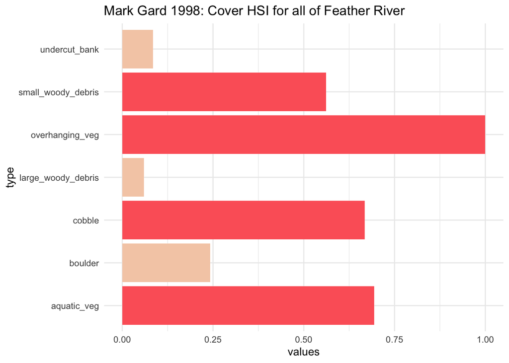

#### Exploring uneven distribution of cover types

Goal: Does it make sense to weight cover variables given some are just inherently less common (ie., undercut bank)

This table shows each cover type and the number of times it is >= to 20%

| type | cover_presence | n |
| --- | --- | --- |
| aquatic_veg | 0 | 7133 |
| aquatic_veg | 1 | 2641 |
| boulder | 0 | 9199 |
| boulder | 1 | 574 |
| cobble | 0 | 7172 |
| cobble | 1 | 2601 |
| large_woody_debris | 0 | 9705 |
| large_woody_debris | 1 | 67 |
| overhanging_veg | 0 | 8033 |
| overhanging_veg | 1 | 1741 |
| small_woody_debris | 0 | 9064 |
| small_woody_debris | 1 | 710 |
| undercut_bank | 0 | 9711 |
| undercut_bank | 1 | 63 |

This table explores potential weighting factors that could be used to achieve a more balanced weighting of each cover type in the HSI analysis

| type | presence | n | sum_n | weighting_factor |
| --- | --- | --- | --- | --- |
| aquatic_veg | 1 | 2641 | 8397 | 0.6854829 |
| boulder | 1 | 574 | 8397 | 0.9316423 |
| cobble | 1 | 2601 | 8397 | 0.6902465 |
| large_woody_debris | 1 | 67 | 8397 | 0.9920210 |
| overhanging_veg | 1 | 1741 | 8397 | 0.7926640 |
| small_woody_debris | 1 | 710 | 8397 | 0.9154460 |
| undercut_bank | 1 | 63 | 8397 | 0.9924973 |

When weighting HSI values by the frequency of observations with a cover type (at least 20%), cobble and aquatic vegetation are no longer above HSI 0.5.

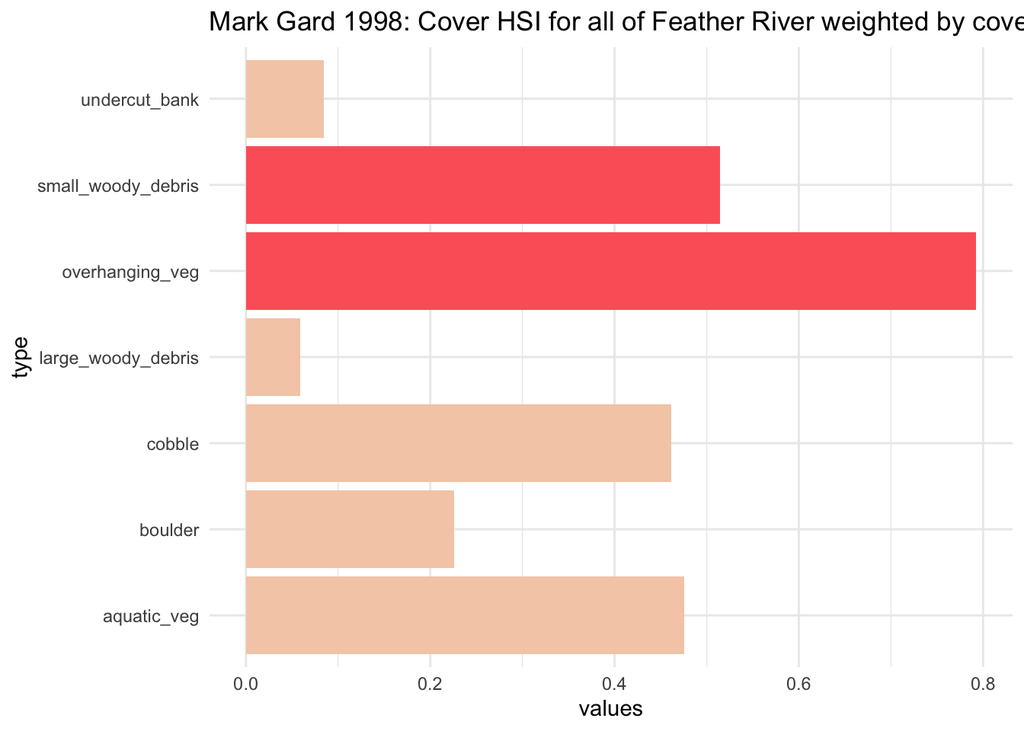

#### Site Level Analysis

Goal 1) compare how site specific HSIs compare across the high and low flow channel, using hatchery ditch (low flow) and g95 (high flow)

Goal 2) how does HSI compare temporally across a single site?

##### Comparing G95 & Hatchery Ditch

Small woody debris and overhanging vegetation are above HSI 0.5 in both locations (which corresponds to what we saw when looking across all locations when weighted), while cobble is above 0.5 only in G95.

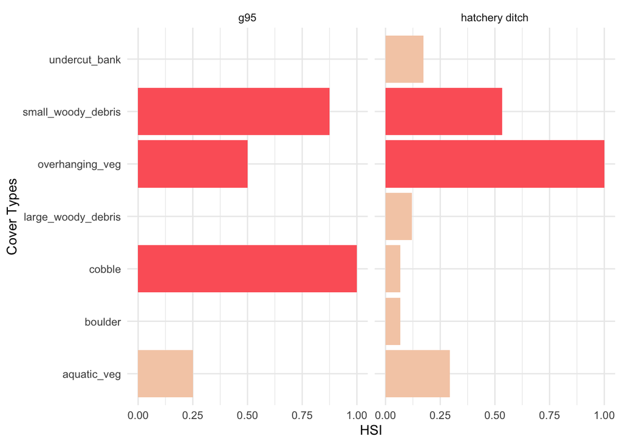

When we apply the weighting factor, the results are similar except that overhanging vegetation only reaches 0.4 in G95 and small woody debris only reaches 0.4 in Hatchery Ditch.

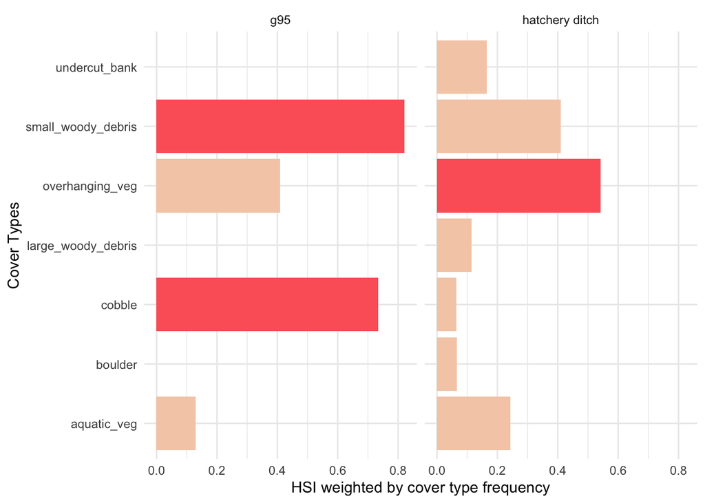

##### Comparing Hatchery Ditch & G95 across months

**Hatchery Ditch**

1. HSI by month

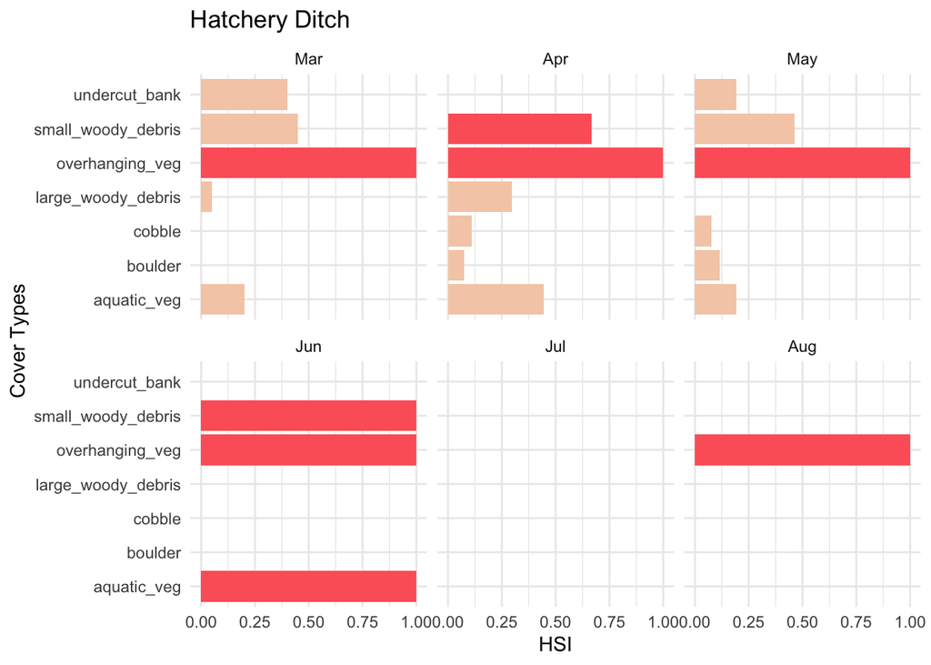

2. Check the number of microhabitat units (by month) where each cover type was greater than 20%

The HSI plot is dependent on these frequencies but is not identical - the HSI 0 may due to no cover or no fish observations.

TODO - remove cover types in the HSI plot that were not present at all

This plot can be used with the HSI plot to inform the interpretation

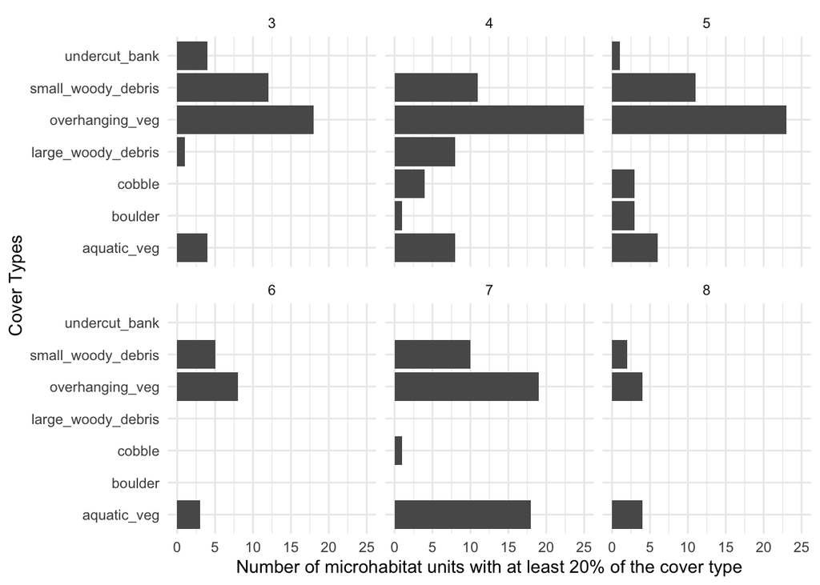

**G95**

1. HSI by month

There were no fish observations after April. Undercut bank, large woody debris, and boulder were rather present in this location. Small woody debris and cobble were only important in March (even though present in April). Overhanging vegetation and aquatic vegetation were only important in April (even though present in March).

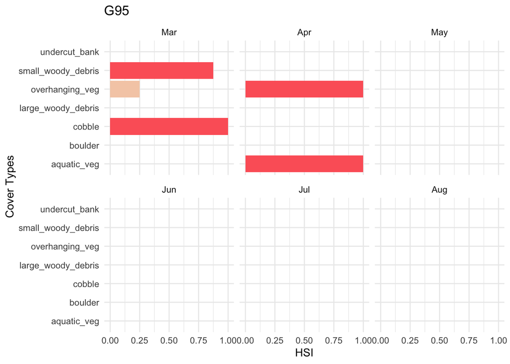

2. Check the number of microhabitat units (by month) where each cover type was greater than 20%

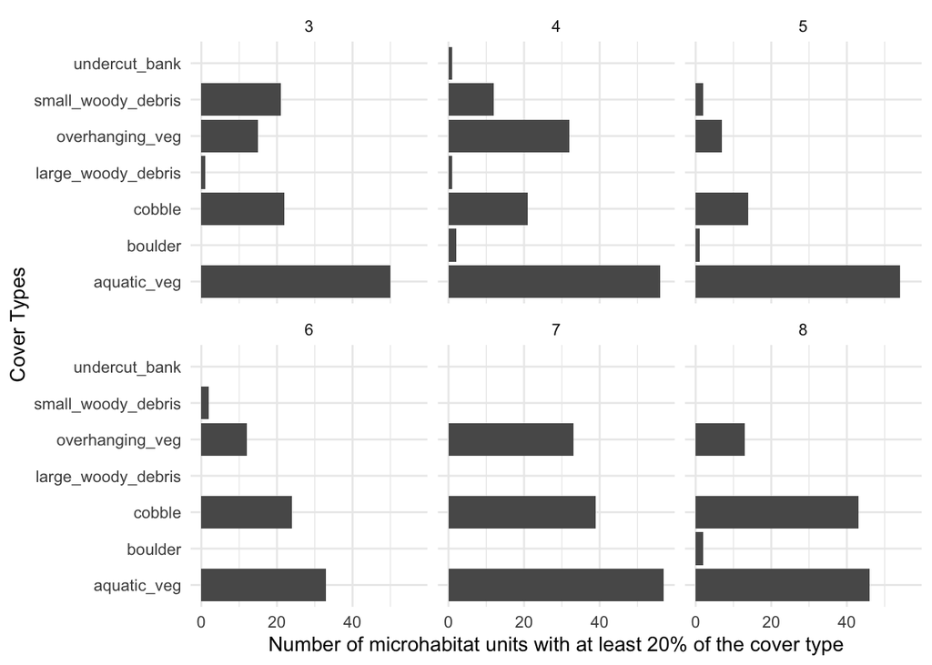

#### Next Steps

**Decisions**

- The HSI’s were developed for fish presence or absence (1/0) regardless of how many fish were present. This was decided to eliminate potential challenges in counting number of fish present and with the assumption that if a fish was present, the habitat is suitable for other fish to also be present.
- Weighting by the relative frequency of each cover type does not drastically change results but should be applied because it makes sense in order to compare across cover types.

**Discussion**

- Sand has a stronger HSI when looking at number of fish vs. presence/absence
- Presence/absence results are consistent with logistic regression
- What is the temporal and spatial scale needed for HSI development?
- Do we want to weight cover variables to better balance HSI?
- There are differences in HSI across time and space. Should we spend more time to characterize these?